# S2MET Mapping Phenotypic Data Summary

## Introduction

This notebook will provide some phenotyping data summaries for the S2MET Mapping project. It will include:

1. Basic model for g + e + gxe
2. Heritability estimates
3. Correlations among environments

```r
library(tidyverse)
library(broom)
library(stringr)
library(readxl)
library(modelr)
library(pbr)
library(rrBLUP)
library(ggridges)
# Project and other directories
source("C:/Users/Jeff/Google Drive/Barley Lab/Projects/S2MET_Mapping/source.R")
tp_geno <- tp_geno_multi
load(file.path(geno_dir, "S2_genos_hmp.RData"))
# Filter environments for those in which the TP was observed
S2_MET_BLUEs_use <- S2_MET_BLUEs %>%
  filter(line_name %in% tp_geno,
         trait != "TestWeight")
```

## Results

### Basic Summaries

Look at the number of lines per environment

| trait | prop_obs |
| --- | --- |
| GrainYield | 0.9827786 |
| HeadingDate | 0.9862507 |
| PlantHeight | 0.9849313 |

Interpretation: of the possible line x environment combinations in which at least one line was observed, the above is the proportion of the lines that were observed.

Visualization of distributions

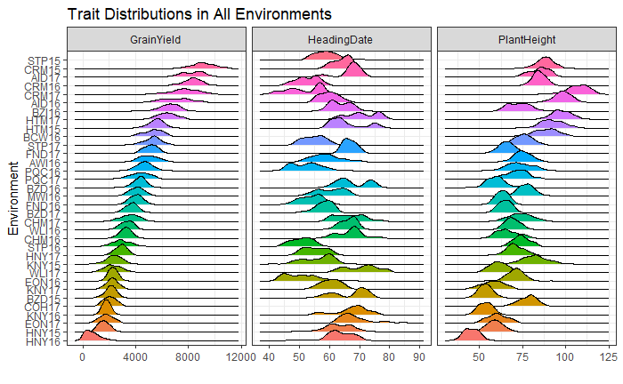

```r
# Sort on grain yield environmental mean
env_order <- S2_MET_BLUEs_use %>%
  mutate_if(is.character, as.factor) %>%
  group_by(environment, trait) %>%
  mutate(env_mean = mean(value, na.rm = TRUE)) %>%
  filter(trait == "GrainYield") %>%
  complete(environment) %>%
  arrange(env_mean) %>%
  pull(environment) %>%
  unique()
(g_met_dist <- S2_MET_BLUEs_use %>%
  filter(trait != "TestWeight") %>%
  mutate(environment = parse_factor(environment, levels = env_order)) %>%
  ggplot(aes(x = value, y = environment, fill = environment)) +
  geom_density_ridges() +
  facet_grid(. ~ trait, scales = "free_x") +
  scale_fill_discrete(guide = FALSE) +
  ylab("Environment") +
  xlab("") +
  labs(title = "Trait Distributions in All Environments") +
  theme_bw() )
# Sort
# Save it
save_file <- file.path(fig_dir, "met_trait_dist.jpg")
ggsave(filename = save_file, plot = g_met_dist, width = 7, height = 5)
```

### Heritability

The heritability will be calcuted for each trait across all environments by fitting the following model:

$$y_{ij} = \mu + g_i + t_j + (gt)_{ij} + \epsilon_{ij}$$

where $y_{ij}$ is the adjusted mean of the *i*th genotype in the *j*th environment, $\mu$ is the grand mean, $g_i$ is the random effect of the *i*th genotype, $t_j$ is the fixed effect of the $j$th environment, $(gt)_{ij}$ is the random effect of the interaction between the $i$th genotype and the $j$th environment, and $\epsilon_{ij}$ is the error associated with the observation.

We will assume the random effects are distributed such that $g \sim N(0, \sigma^2_g)$, $(gt) \sim N(0, \sigma^2_{(gt)})$, and $\epsilon \sim N(0, \mathbf{R}\sigma^2_\epsilon)$, where $\mathbf{R}$ is a diagonal matrix with elements equal to the inverse of the variances of the adjusted genotype means.

```r
    # Fit the models
    fits <- models %>%
      map(~lmer(formula = ., data = df, control = lmer_control, weights = wts))
```

[output not shown]

First test for significance of the $gt$ term using a liklihood ratio test

The likelihood ratio is calculated as

$$LR = -2[\log(L_{Red}) - \log(L_{Full})]$$

The $LR$ is $\chi^2$ distributed with 1 degree of freedom (since we dropped one variance component to get the reduced model). The hypothesis test is $H_0: \sigma^2_i = 0$ and $H_A: \sigma^2_i > 0$

| trait | base | full | lr | p_value |
| --- | --- | --- | --- | --- |
| GrainYield | -48803.26 | -46768.69 | 4069.148 | 0 |
| HeadingDate | -15646.75 | -13772.39 | 3748.711 | 0 |
| PlantHeight | -18720.73 | -17909.14 | 1623.190 | 0 |

The interaction term is significant for all traits

The broad-sense heritability is calculated on a entry-mean basis according to the formula

$$H = \frac{ \sigma^2_G }{ \sigma^2_G + \frac{\sigma^2_{GE}}{r} + \frac{\sigma^2_R}{er} }$$

for overall heritability calculations, and

$$H = \frac{ \sigma^2_G }{ \sigma^2_G + \frac{\sigma^2_R}{r} }$$

where $e$ is the number of environments and $r$ is the number of replicates. In the case of an augmented design, where the number of replicates is uneven, the following formula is used to calculate the harmonic mean of the number of replications:

$$p_h = \frac{n}{\sum^n_{i=1} \frac{1}{p_i}}$$

where $p_h$ is the harmonic mean, $n$ is the number of genotypes, and $p_i$ is the number of replicates of the *i*th genotype.

Now calculate heritability across all environments

| trait | heritability | se | bias | ci_lower | ci_upper |
| --- | --- | --- | --- | --- | --- |
| GrainYield | 0.3064659 | 7.883112e-10 | -2.174301e-10 | 0.3064659 | 0.3064659 |
| HeadingDate | 0.9835915 | 8.620495e-04 | 5.239110e-04 | 0.9816556 | 0.9840481 |
| PlantHeight | 0.9407869 | 5.095747e-03 | -2.938218e-03 | 0.9397063 | 0.9542504 |

```r
# Plot
g_prop_varcomp <- stage_two_prop_varcomp %>%
  ggplot(aes(x = trait, y = prop_vcov, fill = grp)) +
  geom_col() +
  ylab("Proportion") +
  xlab("Trait") +
  scale_fill_discrete(guide = guide_legend(title = "Variance Component")) +
  labs(title = "Proportion of Variance Components to Phenotypic Variance") +
  theme_bw()
```

[output not shown]